# Clinical Test GSE70691

Jessica Scarborough

1/16/2022

# Data Management

## Load signature of interest

```r
de_comp_perc = 0.20
rm_extreme_perc = 0
sam_perm = 10000
mult_perm = 1000
n_folds = 5

# load signature genes
cissig <- readRDS(file = here("Results", "Cisplatin",
                                 paste0("intersect_sig_",
                                        "deCompPerc", de_comp_perc*100,
                                        "_rmExtremePerc", rm_extreme_perc*100,
                                        "_samPerm", sam_perm,
                                        "_multPerm", mult_perm,
                                        "_nFolds", n_folds, ".rds")))

str_flatten(cissig, ", ")
```

```
## [1] "ADAT2, ATP1B3, C15orf41, C1QBP, CDC7, CDCA7, FKBP14, KRT5, LRRC8C, LY6K, MMP10, NPM3, PSAT1, RIOK1, SLFN11, STOML2, USP31, WDR3, ZNF750"
```

## Ingest cleaned data

Cleaned using `download_clean_GSE70691.Rmd` file.

```r
gse4training <- "GSE70691"
gse4testing <- "GSE48276"

data_tidy <- read.csv(here("Data", "GSE", gse4training, "data_tidy.csv")) %>%
  mutate(event = ifelse(censor == "Censored", 0, 1))
```

## Separate adjuvant and NAC treated samples

```r
data_adj <- data_tidy %>%
   filter(tx == "adjuvant MVAC")

data_nac <- data_tidy %>%
   filter(tx == "NAC-MVAC")
```

# Data Visualization

Here, we’ll look at the distribution of our signature genes.

```r
# convert to long format for easy plotting
ex_long <- data_nac %>%
   select(all_of(cissig)) %>%
   pivot_longer(cols = cissig, names_to = "gene", values_to = "expression")
```

```
## Note: Using an external vector in selections is ambiguous.
## ℹ Use `all_of(cissig)` instead of `cissig` to silence this message.
## ℹ See <https://tidyselect.r-lib.org/reference/faq-external-vector.html>.
```

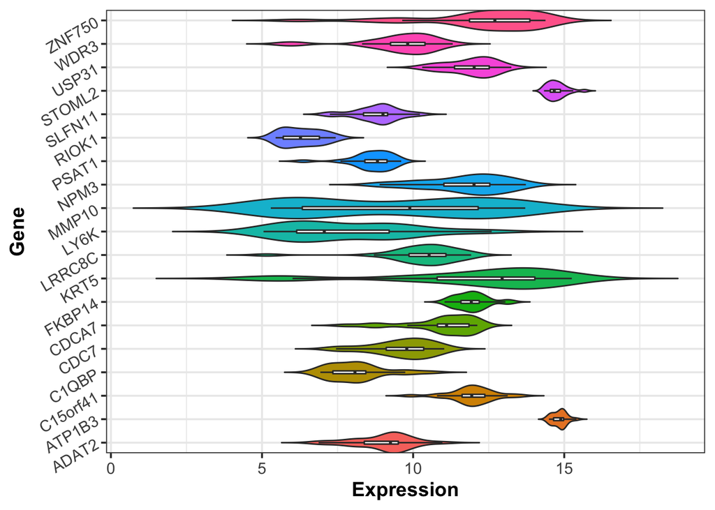

```r
# plot violin for each gene's distribution among all samples
ggplot(ex_long, aes(x = gene, y=expression)) +
  geom_violin(trim = FALSE, scale = "width", aes(fill=gene)) +
  geom_boxplot(width = 0.12, outlier.shape = NA) +
  scale_x_discrete(expand = c(0,0)) +
  # geom_label(aes(x = subtype, y = 28.5, label = n), data = median_group,
  # label.padding = unit(0.15, "lines")) +
  coord_flip() +
  ylab("Expression") + xlab("Gene") +
  theme_bw(base_size = 14) +
  theme(axis.text.y = element_text(angle = 30),
    axis.title=element_text(face="bold"),
        legend.position = "none")
```

Remove genes with very low variance.

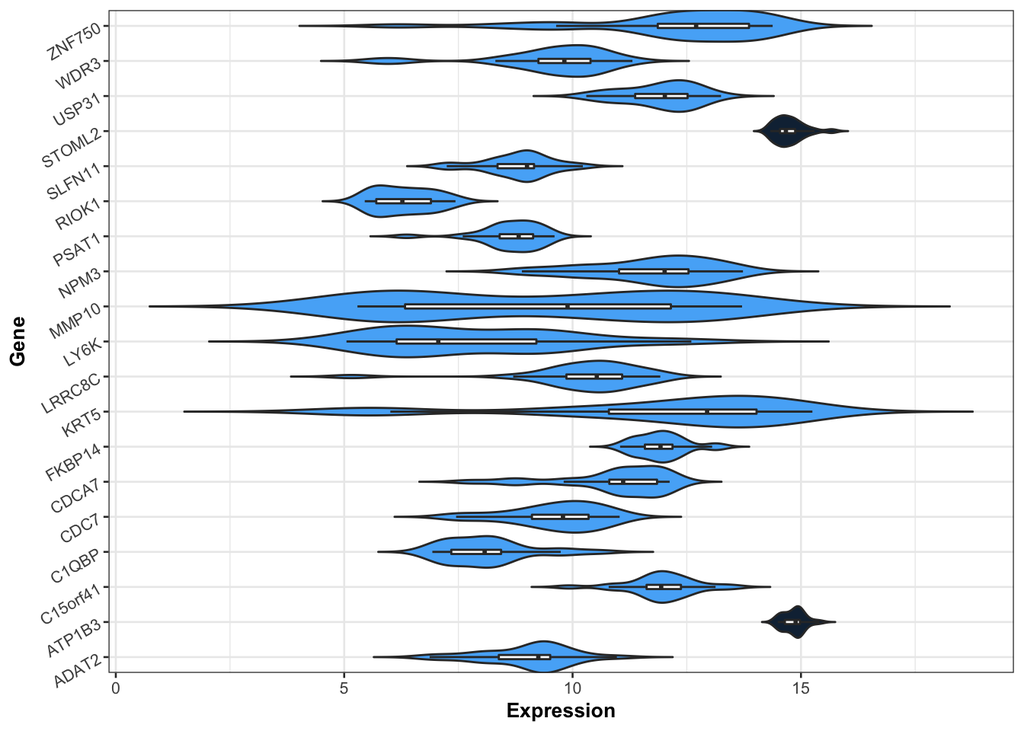

```r
# label gene with variance
ex_long_group <- ex_long %>%
   dplyr::select(gene, expression) %>%
   group_by(gene) %>%
   dplyr::summarize(variance = var(expression)) %>%
   arrange(variance) %>%
   mutate(var_high = if_else(variance > 0.2, 1, 0))

# merge variance labels with original long dataset
ex_long_var <- ex_long_group %>%
   inner_join(ex_long, by = "gene")

# same violin plot as above, colored by variance label (high/low)
ggplot(ex_long_var, aes(x = gene, y=expression)) +
  geom_violin(trim = FALSE, scale = "width", aes(fill=var_high)) +
  geom_boxplot(width = 0.12, outlier.shape = NA) +
  scale_x_discrete(expand = c(0,0)) +
  # geom_label(aes(x = subtype, y = 28.5, label = n), data = median_group,
  # label.padding = unit(0.15, "lines")) +
  coord_flip() +
  ylab("Expression") + xlab("Gene") +
  theme_bw(base_size = 10) +
  theme(axis.text.y = element_text(angle = 30),
    axis.title=element_text(face="bold"),
        legend.position = "none")
```

```r
# create vector of only cissig genes with high variance
cissig_highvar <- ex_long_var %>%
   filter(var_high == 1) %>%
   pull(gene)

cissig_highvar <- unique(cissig_highvar)
```

# Data Analysis

We’ll start by creating our `Surv` objects. We’ll need one for the cohort that received NAC and the one that received adjuvant chemo.

```r
surv_nac_os <- Surv(time = data_nac$survival_mo,
                         event = data_nac$event)

surv_adj_os <- Surv(time = data_adj$survival_mo,
                         event = data_adj$event)
```

## Univariate survival analysis

```r
# Surv object for use in `coxph` function
surv_nac_os <- Surv(time = data_nac$survival_mo,
                         event = data_nac$event)

# initiate vector to hold genes that indicate decreased risk of event with increased expression
# ≈ increased expression ≈ improved response to treatment ≈ greater cisplatin sensitivity
sens_genes <- c()

# loop through each gene with reassonable variance
for (gene in cissig_highvar){
   # temp data because you can't use a character in the coxph formula, allows use of .
   tempData <- data_nac %>% dplyr::select(gene)
   cfit <- coxph(surv_nac_os ~ ., data = tempData)
   print(summary(cfit)) # just for ease of viewing, can be commented out
   # if (cfit$coefficients < -0.5 |
   #     (summary(cfit)$logtest["pvalue"] < 0.2 & cfit$coefficients < 0)){
   # if (summary(cfit)$logtest["pvalue"] < 0.2 & cfit$coefficients < 0){
   if (cfit$coefficients < -0.5){
      print(summary(cfit))
      sens_genes <- c(sens_genes, gene)
   }
}
```

```
## Note: Using an external vector in selections is ambiguous.
## ℹ Use `all_of(gene)` instead of `gene` to silence this message.
## ℹ See <https://tidyselect.r-lib.org/reference/faq-external-vector.html>.
```

```
## Call:
## coxph(formula = surv_nac_os ~ ., data = tempData)
##
##   n= 22, number of events= 17
##
##           coef exp(coef) se(coef)      z Pr(>|z|)
## FKBP14 -0.5186    0.5954   0.4918 -1.055    0.292
##
##        exp(coef) exp(-coef) lower .95 upper .95
## FKBP14    0.5954       1.68    0.2271     1.561
##
## Concordance= 0.538  (se = 0.085 )
## Likelihood ratio test= 1.2  on 1 df,   p=0.3
## Wald test            = 1.11  on 1 df,   p=0.3
## Score (logrank) test = 1.12  on 1 df,   p=0.3
##
## Call:
## coxph(formula = surv_nac_os ~ ., data = tempData)
##
##   n= 22, number of events= 17
##
##           coef exp(coef) se(coef)      z Pr(>|z|)
## FKBP14 -0.5186    0.5954   0.4918 -1.055    0.292
##
##        exp(coef) exp(-coef) lower .95 upper .95
## FKBP14    0.5954       1.68    0.2271     1.561
##
## Concordance= 0.538  (se = 0.085 )
## Likelihood ratio test= 1.2  on 1 df,   p=0.3
## Wald test            = 1.11  on 1 df,   p=0.3
## Score (logrank) test = 1.12  on 1 df,   p=0.3
##
## Call:
## coxph(formula = surv_nac_os ~ ., data = tempData)
##
##   n= 22, number of events= 17
##
##          coef exp(coef) se(coef)      z Pr(>|z|)
## RIOK1 -0.2052    0.8145   0.4325 -0.474    0.635
##
```

[output cut: 272 more lines]

```
## Call:
## coxph(formula = surv_nac_os ~ ., data = tempData)
##
##   n= 22, number of events= 17
##
##           coef exp(coef) se(coef)      z Pr(>|z|)
## MMP10 -0.01482   0.98529  0.08207 -0.181    0.857
##
##       exp(coef) exp(-coef) lower .95 upper .95
## MMP10    0.9853      1.015    0.8389     1.157
##
## Concordance= 0.538  (se = 0.077 )
## Likelihood ratio test= 0.03  on 1 df,   p=0.9
## Wald test            = 0.03  on 1 df,   p=0.9
## Score (logrank) test = 0.03  on 1 df,   p=0.9
```

```r
# save list of genes that are related to cisplatin sensitivity in this analysis
saveRDS(sens_genes, file = here("Results", "Cisplatin", paste0("cissig_trimmed_", gse4training, ".rds")))
```

## Multivariate analysis

### Training model

Using sensitivity genes from univariate analysis

```r
# sensData <- data_nac %>% dplyr::select(all_of(cissig_highvar))
# cfit_yeschemo_nograde <- coxph(surv_nac_os ~ ., data = sensData)
# summary(cfit_yeschemo_nograde)

# select only genes from `sens_genes`, again to be able to use . in formula
sensData <- data_nac %>% dplyr::select(all_of(sens_genes))
cfit_yeschemo_nograde <- coxph(surv_nac_os ~ ., data = sensData)
summary(cfit_yeschemo_nograde)
```

```
## Call:
## coxph(formula = surv_nac_os ~ ., data = sensData)
##
##   n= 22, number of events= 17
##
##             coef exp(coef) se(coef)      z Pr(>|z|)
## FKBP14   -0.3735    0.6883   0.5040 -0.741   0.4586
## PSAT1    -0.2059    0.8139   0.5684 -0.362   0.7172
## C15orf41 -0.6801    0.5066   0.3784 -1.797   0.0723 .
## ---
## Signif. codes:  0 '***' 0.001 '**' 0.01 '*' 0.05 '.' 0.1 ' ' 1
##
##          exp(coef) exp(-coef) lower .95 upper .95
## FKBP14      0.6883      1.453    0.2563     1.848
## PSAT1       0.8139      1.229    0.2672     2.480
## C15orf41    0.5066      1.974    0.2413     1.063
##
## Concordance= 0.679  (se = 0.082 )
## Likelihood ratio test= 6.47  on 3 df,   p=0.09
## Wald test            = 6.53  on 3 df,   p=0.09
## Score (logrank) test = 7.08  on 3 df,   p=0.07
```

```r
saveRDS(cfit_yeschemo_nograde, file = here("Results", "Cisplatin",
                                           paste0("surv_model_trimmedgenes_nograde_",
                                                  gse4training, ".rds"))) # this is our final model
```

### Assessing trained model on original data

Create linear predictor for each sample, classify samples to cohorts based on linear predictor.

```r
data_nac$pred_lp <- predict(cfit_yeschemo_nograde, type = "lp")

data_nac <- data_nac %>%
      mutate(pred_2grp_med = factor(case_when(pred_lp < median(pred_lp) ~ "1_Low",
                                              pred_lp >= median(pred_lp) ~ "2_High"),
                             ordered = TRUE),
          pred_3grp_tert = factor(case_when(pred_lp < quantile(pred_lp, 0.33) ~ "1_Low",
                                pred_lp >= quantile(pred_lp, 0.33) &
                                   pred_lp < quantile(pred_lp, 0.66) ~ "2_Middle",
                                pred_lp >= quantile(pred_lp, 0.66) ~ "3_High"),
                                ordered = TRUE),
          pred_3grp_2550 = factor(case_when(pred_lp < quantile(pred_lp, 0.25) ~ "1_Low",
                                pred_lp >= quantile(pred_lp, 0.25) &
                                   pred_lp < quantile(pred_lp, 0.75) ~ "2_Middle",
                                pred_lp >= quantile(pred_lp, 0.75) ~ "3_High"),
                                ordered = TRUE),
          pred_quar = factor(case_when(pred_lp < quantile(pred_lp, 0.25) ~ "1_Low",
                                pred_lp >= quantile(pred_lp, 0.25) &
                                   pred_lp < quantile(pred_lp, 0.50) ~ "2_Middle Low",
                                pred_lp >= quantile(pred_lp, 0.50) &
                                   pred_lp < quantile(pred_lp, 0.75) ~ "3_Middle High",
                                pred_lp >= quantile(pred_lp, 0.75) ~ "4_High"),
                             ordered = TRUE))
```

Plot KM curves based on linear predictor cohorts

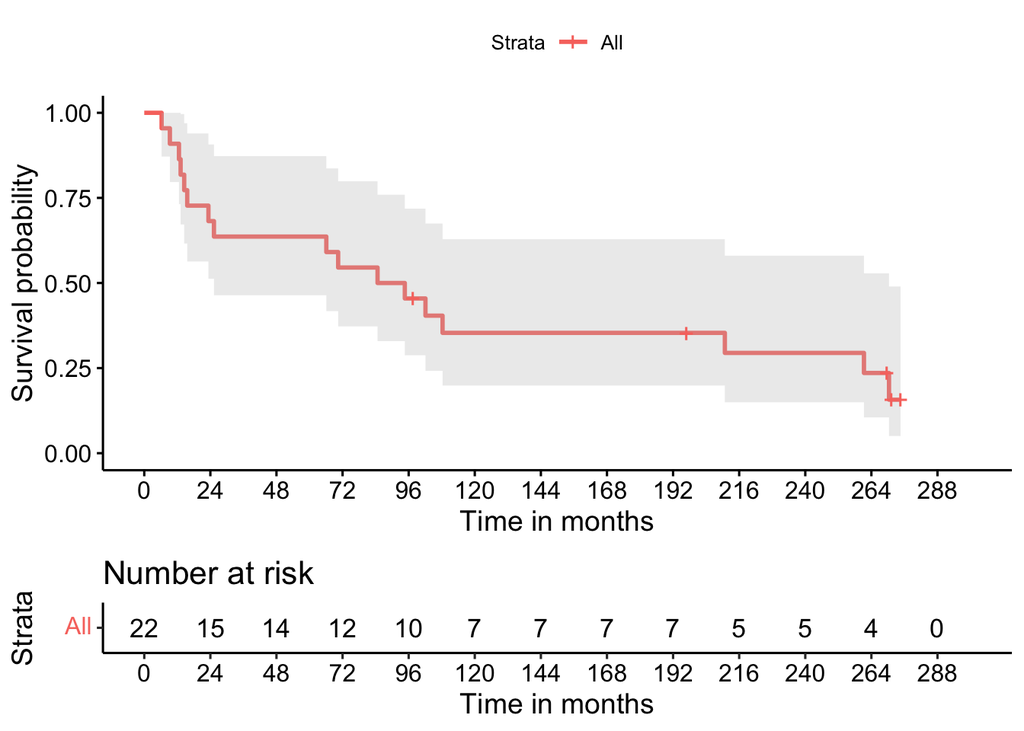

```r
# surv_nac_os <- Surv(time = data_nac$survival_mo,
#                          event = data_nac$event)

## ## ## ## ## ## ## ## ## ## ## ## ## ## ## ## ## ## ## ## ## ## ## ## ##

## Intercept only

km_yeschemo_int <- survfit(surv_nac_os ~ 1)

ggsurvplot(km_yeschemo_int, data = data_nac,
   conf.int = TRUE, # Add confidence interval
   risk.table = TRUE, # Add risk table
   xlab = "Time in months", # adjust X axis label
   break.time.by = 24 # add tick every 12 months
   )
```

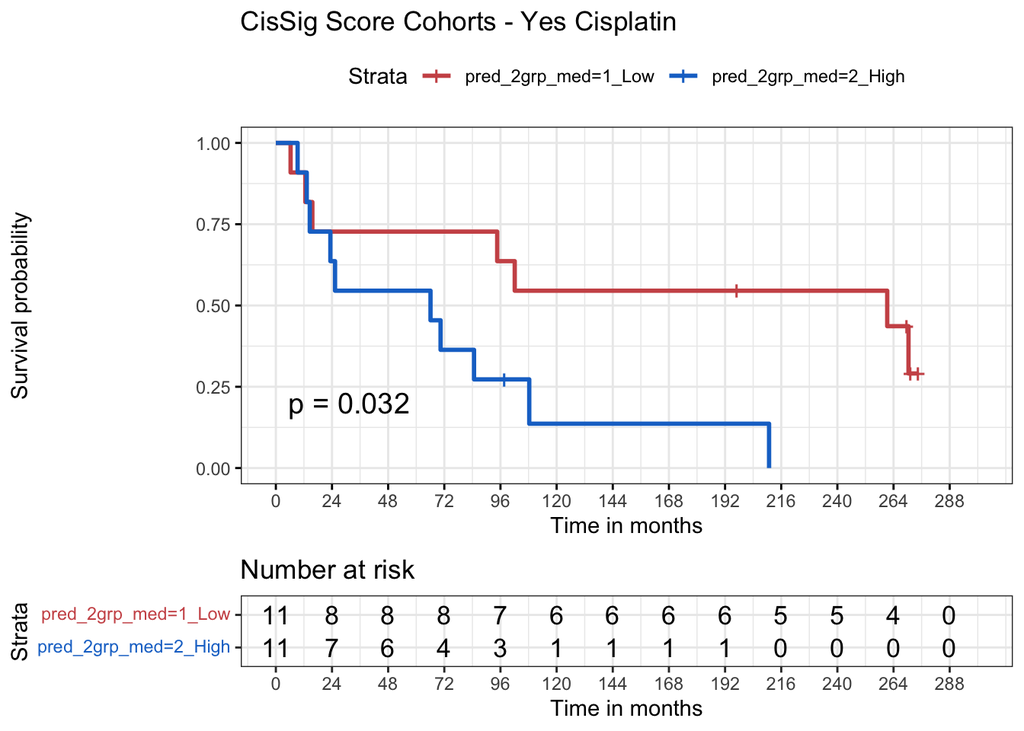

```r
## ## ## ## ## ## ## ## ## ## ## ## ## ## ## ## ## ## ## ## ## ## ## ## ##

## Top/bottom halves

km_yeschemo_css_new <- survfit(surv_nac_os ~ data_nac$pred_2grp_med)

ggsurvplot(km_yeschemo_css_new, data = data_nac, size = 1,
   palette = c("indianred3", "dodgerblue3"), # custom colors
   conf.int = FALSE, # Add confidence interval
   pval = TRUE, # Add p-value
   risk.table = TRUE, # Add risk table
   risk.table.height = 0.250, # change if you have >2 groups
   risk.table.y.text.col = T, # show colors in table listing
   ncensor.plot = FALSE,
   ncensor.plot.height = 0.25,
   xlab = "Time in months", # adjust X axis label
   break.time.by = 24, # break X axis in time intervals
   # legend.labs = c("High Linear Pred.", "Low Linear Pred."),
   # labels are opposite of "Cissig score, where higher equals better outcomes
   title = "CisSig Score Cohorts - Yes Cisplatin",
   ggtheme = theme_bw() # Change ggplot2 theme
   )
```

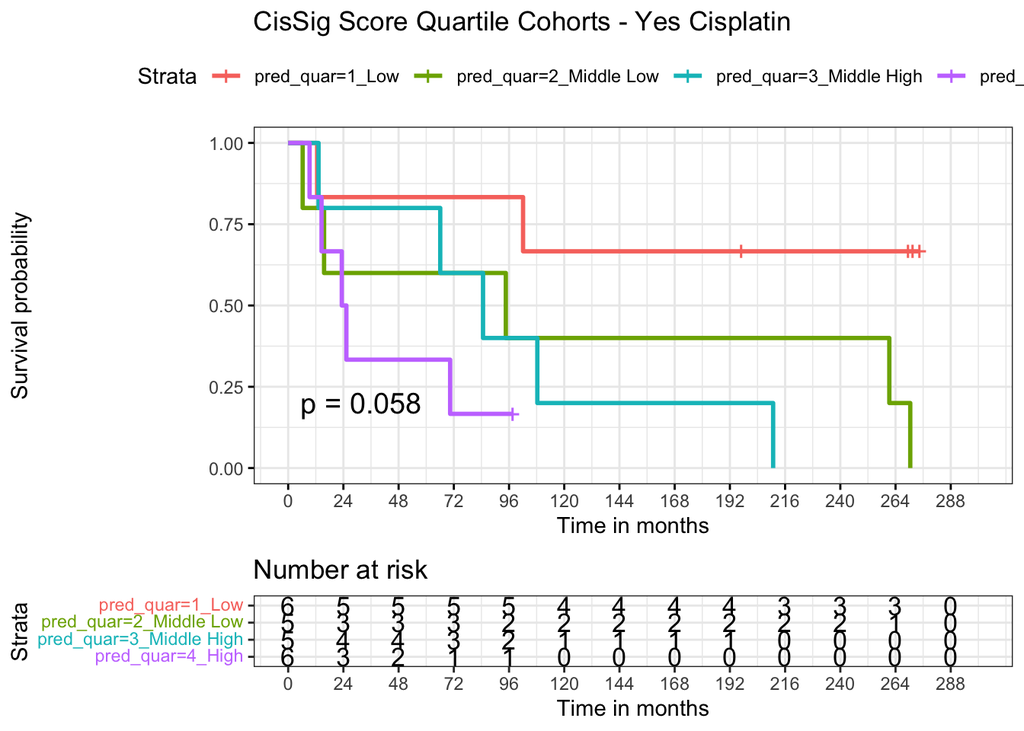

```r
## ## ## ## ## ## ## ## ## ## ## ## ## ## ## ## ## ## ## ## ## ## ## ## ##

## Quartiles

km_yeschemo_css_quar <- survfit(surv_nac_os ~ data_nac$pred_quar)

ggsurvplot(km_yeschemo_css_quar, data = data_nac, size = 1,
   conf.int = FALSE, # Add confidence interval
   pval = TRUE, # Add p-value
   risk.table = TRUE, # Add risk table
   risk.table.height = 0.25, # change if you have >2 groups
   risk.table.y.text.col = T, # show colors in table listing
   ncensor.plot = FALSE,
   ncensor.plot.height = 0.25,
   xlab = "Time in months", # adjust X axis label
   break.time.by = 24, # break X axis in time intervals
   # legend.labs = c("Quar 4 Lin Pred.", "Quar 3 Lin Pred.",
   #                 "Quar 2 Lin Pred.", "Quar 1 Lin Pred."), # labels
   title = "CisSig Score Quartile Cohorts - Yes Cisplatin",
   ggtheme = theme_bw() # Change ggplot2 theme
   )
```

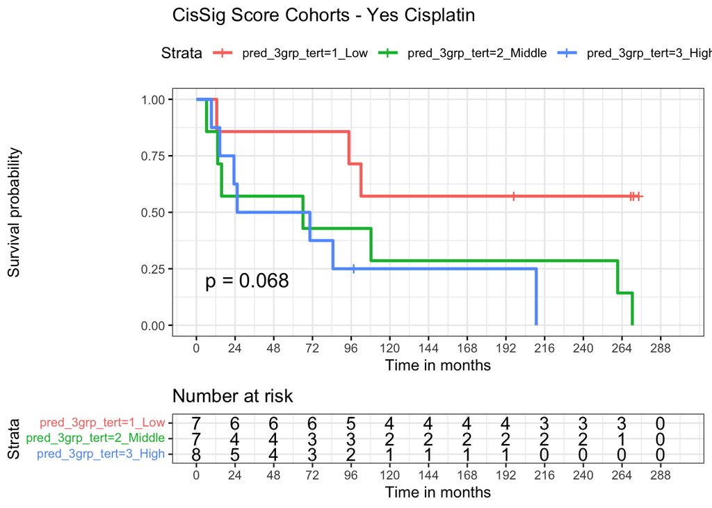

```r
## ## ## ## ## ## ## ## ## ## ## ## ## ## ## ## ## ## ## ## ## ## ## ## ##
## Tertiles

km_yeschemo_css_tert_by33 <- survfit(surv_nac_os ~ data_nac$pred_3grp_tert)

ggsurvplot(km_yeschemo_css_tert_by33, data = data_nac, size = 1,
   conf.int = FALSE, # Add confidence interval
   pval = TRUE, # Add p-value
   risk.table = TRUE, # Add risk table
   risk.table.height = 0.250, # change if you have >2 groups
   risk.table.y.text.col = T, # show colors in table listing
   ncensor.plot = FALSE,
   ncensor.plot.height = 0.25,
   xlab = "Time in months", # adjust X axis label
   break.time.by = 24, # break X axis in time intervals
   # legend.labs = c("High Linear Pred.", "Low Linear Pred."),
   # labels are opposite of "Cissig score, where higher equals better outcomes
   title = "CisSig Score Cohorts - Yes Cisplatin",
   ggtheme = theme_bw() # Change ggplot2 theme
   )
```

```r
## ## ## ## ## ## ## ## ## ## ## ## ## ## ## ## ## ## ## ## ## ## ## ## ##
```

# Validation of GSE48276 model (`gse4testing`)

The code up until this point in the `clinical_test_GSE48276.Rmd` file must be run (in order to have the model that we are about to load).

```r
model_GSE48276 <- readRDS(here("Results", "Cisplatin",
                               paste0("surv_model_trimmedgenes_nograde_", gse4testing, ".rds")))
```

## Predict GSE70691 (`gse4training`) on GSE48276 (`gse4testing`) trained model

We’re testing the model build with (GSE48276) on patients in the current dataset (GSE70691). First, we’ll assign a linear predictor to each of the samples.

```r
# create predictions
data_nac$pred_lp <- predict(model_GSE48276, newdata = data_nac, type = "lp")
```

## Find optimal cutpoints

Next, we’ll find sweep all cutpoint options to find the optimal cutpoint for two (`sweep_cutpoints1`) and three (`sweep_cutpoints2`) groups.

```r
sweep_cutpoints1 <- function(tidy_data, surv_obj){
   cutpoints = quantile(tidy_data$pred_lp, prob = seq(0, 1, 0.01))[-(1:5)]
   cutpoints = cutpoints[-(96:101)]
   cutpoint_vec <- c()
   chisq_vec <- c()
   low_n_vec <- c()
   high_n_vec <- c()
   for (i in 1:length(cutpoints)){
      tidy_data_labs <- tidy_data %>%
         mutate(pred_group = ifelse(pred_lp <= cutpoints[i], "low", "high"))
      survdiff_results <- survdiff(surv_obj ~ pred_group, data = tidy_data_labs)
      chisq_vec <- c(chisq_vec, survdiff_results$chisq)
      cutpoint_vec <- c(cutpoint_vec, cutpoints[i])
      low_n_vec <- c(low_n_vec, nrow(tidy_data_labs %>% filter(pred_group == "low")))
      high_n_vec <- c(high_n_vec, nrow(tidy_data_labs %>% filter(pred_group == "high")))
   }
   data.frame(cutpoint = cutpoint_vec,
              low_n = low_n_vec,
              high_n = high_n_vec,
              chisq = chisq_vec) %>%
      rowwise() %>%
      mutate(min_n = min(low_n, high_n)) %>%
      ungroup()
}

cutpoints_1 <- sweep_cutpoints1(data_nac, surv_nac_os)

cutpoints_1_n4 <- cutpoints_1 %>%
   filter(min_n >= 4) %>% #require at least 4 samples in each group
   filter(chisq == max(chisq)) # cutpoints with the highest chisq result

# they all cut the data with the same samples in each group
# taking the first row for consistency
single_cutpoint_best <- cutpoints_1_n4$cutpoint[1]

sweep_cutpoints2 <- function(tidy_data, surv_obj){
   cutpoints_first = quantile(tidy_data$pred_lp, prob = seq(0, 1, 0.01))[-(1:5)]
   cutpoints_first = cutpoints_first[-(96:101)]
   cutpoint_first_vec <- c()
   cutpoint_second_vec <- c()
   low_n_vec <- c()
   middle_n_vec <- c()
   high_n_vec <- c()
   chisq_vec <- c()
   for (i in 1:length(cutpoints_first)){
      pred_lp_after_cutoff <- tidy_data$pred_lp[tidy_data$pred_lp > min(cutpoints_first)]
      cutpoints_second <- quantile(pred_lp_after_cutoff, prob = seq(0, 1, 0.01))[-(1:5)]
      cutpoints_second <- cutpoints_second[-(96:101)]
      for (j in 1:length(cutpoints_second)){
         tidy_data_labs <- tidy_data %>%
            mutate(pred_group = case_when(pred_lp <= cutpoints_first[i] ~ "low",
                                          pred_lp > cutpoints_first[i] &
                                             pred_lp <= cutpoints_second[j] ~ "middle",
                                          pred_lp > cutpoints_second[j] ~ "high"))
         survdiff_results <- survdiff(surv_obj ~ pred_group, data = tidy_data_labs)
         chisq_vec <- c(chisq_vec, survdiff_results$chisq)
         cutpoint_first_vec <- c(cutpoint_first_vec, cutpoints_first[[i]])
         cutpoint_second_vec <- c(cutpoint_second_vec, cutpoints_second[[j]])
         low_n_vec <- c(low_n_vec, nrow(tidy_data_labs %>% filter(pred_group == "low")))
         middle_n_vec <- c(middle_n_vec, nrow(tidy_data_labs %>% filter(pred_group == "middle")))
         high_n_vec <- c(high_n_vec, nrow(tidy_data_labs %>% filter(pred_group == "high")))
      }
   }
   data.frame(cutpoint1 = cutpoint_first_vec,
              cutpoint2 = cutpoint_second_vec,
              low_n = low_n_vec,
              middle_n = middle_n_vec,
              high_n = high_n_vec,
              chisq = chisq_vec) %>%
      rowwise() %>%
      mutate(min_n = min(low_n, middle_n, high_n)) %>%
      ungroup()
}


cutpoints_2 <- sweep_cutpoints2(data_nac, surv_nac_os)
saveRDS(cutpoints_2, here("Results", "Cisplatin", "Plots", "External_Clinical_Testing",
                          paste0("opt_2cutpoints_", gse4testing, "trained_",
                                 gse4training, "tested.rds")))

# cutpoints_2 <- readRDS(here("Results", "Cisplatin", "Plots", "External_Clinical_Testing",
#                             paste0("opt_2cutpoints_", gse4testing, "trained_",
#                                    gse4training, "_tested.rds")))

cutpoints_2_n4 <- cutpoints_2 %>%
   filter(min_n >= 4) %>% #require at least 4 samples in each group
   filter(chisq == max(chisq)) # cutpoints with the highest chisq result


# they all cut the data with the same samples in each group
# taking the first row for consistency
double_cutpoint_best <- c(cut1 = cutpoints_2_n4$cutpoint1[1],
                          cut2 = cutpoints_2_n4$cutpoint2[1])
```

## Classify predictions

```r
# classify predictions
data_nac <- data_nac %>%
      mutate(pred_2grp_med = factor(case_when(pred_lp < median(pred_lp) ~ "1_Low",
                                              pred_lp >= median(pred_lp) ~ "2_High"),
                             ordered = TRUE),
          pred_2grp_optimal = case_when(pred_lp < single_cutpoint_best ~ "1_Low",
                                        pred_lp >= single_cutpoint_best ~ "2_High"),
          pred_3grp_tert = factor(case_when(pred_lp < quantile(pred_lp, 0.33) ~ "1_Low",
                                pred_lp >= quantile(pred_lp, 0.33) &
                                   pred_lp < quantile(pred_lp, 0.66) ~ "2_Middle",
                                pred_lp >= quantile(pred_lp, 0.66) ~ "3_High"),
                                ordered = TRUE),
          pred_3grp_optimal = case_when(pred_lp <= double_cutpoint_best["cut1"] ~ "1_Low",
                                pred_lp > double_cutpoint_best["cut1"] &
                                   pred_lp <= double_cutpoint_best["cut2"] ~ "2_Middle",
                                pred_lp > double_cutpoint_best["cut2"] ~ "3_High"),
          pred_3grp_2550 = factor(case_when(pred_lp < quantile(pred_lp, 0.25) ~ "1_Low",
                                pred_lp >= quantile(pred_lp, 0.25) &
                                   pred_lp < quantile(pred_lp, 0.75) ~ "2_Middle",
                                pred_lp >= quantile(pred_lp, 0.75) ~ "3_High"),
                                ordered = TRUE),
          pred_quar = factor(case_when(pred_lp < quantile(pred_lp, 0.25) ~ "1_Low",
                                pred_lp >= quantile(pred_lp, 0.25) &
                                   pred_lp < quantile(pred_lp, 0.50) ~ "2_Middle Low",
                                pred_lp >= quantile(pred_lp, 0.50) &
                                   pred_lp < quantile(pred_lp, 0.75) ~ "3_Middle High",
                                pred_lp >= quantile(pred_lp, 0.75) ~ "4_High"),
                             ordered = TRUE))
```

Plot KM curves based on linear predictor cohorts

```r
## ## ## ## ## ## ## ## ## ## ## ## ## ## ## ## ## ## ## ## ## ## ## ## ##

## Intercept only

km_yeschemo_int <- survfit(surv_nac_os ~ 1)

gg_int <- ggsurvplot(km_yeschemo_int, data = data_nac,
   conf.int = TRUE, # Add confidence interval
   risk.table = TRUE, # Add risk table
   xlab = "Time in months", # adjust X axis label
   xlim = c(0, 288),
   break.time.by = 24, # add tick every 12 months
   title = "Yes Cisplatin" + theme(plot.title = element_text(hjust = 0.5))
   )

## ## ## ## ## ## ## ## ## ## ## ## ## ## ## ## ## ## ## ## ## ## ## ## ##

## Top/bottom halves

km_yeschemo_css_new <- survfit(surv_nac_os ~ data_nac$pred_2grp_med)

gg_grp2_med <- ggsurvplot(km_yeschemo_css_new, data = data_nac, size = 1,
   palette = c("indianred3", "dodgerblue3"), # custom colors
   conf.int = FALSE, # Add confidence interval
   pval = TRUE, # Add p-value
   risk.table = TRUE, # Add risk table
   risk.table.height = 0.250, # change if you have >2 groups
   risk.table.y.text.col = T, # show colors in table listing
   ncensor.plot = FALSE,
   ncensor.plot.height = 0.25,
   xlab = "Time in months", # adjust X axis label
   xlim = c(0, 288),
   break.time.by = 24, # break X axis in time intervals
   # legend.labs = c("High Linear Pred.", "Low Linear Pred."),
   # labels are opposite of "Cissig score, where higher equals better outcomes
   # title = "CisSig Score Cohorts - Yes Cisplatin",
   legend.labs = c("Low Risk", "High Risk"),
   title = "Yes Cisplatin",
   ggtheme = theme_bw() + theme(plot.title = element_text(hjust = 0.5))
   )

## ## ## ## ## ## ## ## ## ## ## ## ## ## ## ## ## ## ## ## ## ## ## ## ##

## Optimal 2 group cutpoints

km_yeschemo_css_2grp_opt <- survfit(surv_nac_os ~ data_nac$pred_2grp_optimal)

gg_grp2_opt <- ggsurvplot(km_yeschemo_css_2grp_opt, data = data_nac, size = 1,
   palette = c("indianred3", "dodgerblue3"), # custom colors
   conf.int = FALSE, # Add confidence interval
   pval = TRUE, # Add p-value
   risk.table = TRUE, # Add risk table
   risk.table.height = 0.25, # change if you have >2 groups
   risk.table.y.text.col = T, # show colors in table listing
   ncensor.plot = FALSE,
   ncensor.plot.height = 0.25,
   xlab = "Time in months", # adjust X axis label
   xlim = c(0, 288),
   break.time.by = 24, # break X axis in time intervals
   # legend.labs = c("Lowest third Lin Pred.", "Middle third Lin Pred.",
   # "Top third Lin Pred."), # labels
   # title = "CisSig Score 2 Cohorts (optimal) - Yes Cisplatin",
   legend.labs = c("Low Risk", "High Risk"),
   title = "Yes Cisplatin",
   ggtheme = theme_bw() + theme(plot.title = element_text(hjust = 0.5))
   )

## ## ## ## ## ## ## ## ## ## ## ## ## ## ## ## ## ## ## ## ## ## ## ## ##

## Tertiles by 33%

km_yeschemo_css_tert_by33 <- survfit(surv_nac_os ~ data_nac$pred_3grp_tert)

gg_grp3_tert <- ggsurvplot(km_yeschemo_css_tert_by33, data = data_nac, size = 1,
   conf.int = FALSE, # Add confidence interval
   pval = TRUE, # Add p-value
   risk.table = TRUE, # Add risk table
   risk.table.height = 0.25, # change if you have >2 groups
   risk.table.y.text.col = T, # show colors in table listing
   ncensor.plot = FALSE,
   ncensor.plot.height = 0.25,
   xlab = "Time in months", # adjust X axis label
   xlim = c(0, 288),
   break.time.by = 24, # break X axis in time intervals
   # legend.labs = c("Lowest third Lin Pred.", "Middle third Lin Pred.",
   # "Top third Lin Pred."), # labels
   # title = "CisSig Score Tertile Cohorts (by 33%) - Yes Cisplatin",
   legend.labs = c("Low Risk", "Middle Risk", "High Risk"),
   title = "Yes Cisplatin",
   ggtheme = theme_bw() + theme(plot.title = element_text(hjust = 0.5))
   )

## ## ## ## ## ## ## ## ## ## ## ## ## ## ## ## ## ## ## ## ## ## ## ## ##

## Tertiles by 25/50/25%

km_yeschemo_css_tert_by25_50_25 <- survfit(surv_nac_os ~
                                              data_nac$pred_3grp_2550)

gg_grp3_2550 <- ggsurvplot(km_yeschemo_css_tert_by25_50_25, data = data_nac, size = 1,
   conf.int = FALSE, # Add confidence interval
   pval = TRUE, # Add p-value
   risk.table = TRUE, # Add risk table
   risk.table.height = 0.25, # change if you have >2 groups
   risk.table.y.text.col = T, # show colors in table listing
   ncensor.plot = FALSE,
   ncensor.plot.height = 0.25,
   xlab = "Time in months", # adjust X axis label
   xlim = c(0, 288),
   break.time.by = 24, # break X axis in time intervals
   # legend.labs = c("Bottom 25% Lin Pred.", "Middle 25-75% Lin Pred.",
   # "Top 25% Lin Pred."), # labels
   # title = "CisSig Score Tertile Cohorts (by 25/50/25%) - Yes Cisplatin",
   legend.labs = c("Low Risk", "Middle Risk", "High Risk"),
   title = "Yes Cisplatin",
   ggtheme = theme_bw() + theme(plot.title = element_text(hjust = 0.5))
   )

## ## ## ## ## ## ## ## ## ## ## ## ## ## ## ## ## ## ## ## ## ## ## ## ##

## Optimal 3 group cutpoints

km_yeschemo_css_tert_opt <- survfit(surv_nac_os ~ data_nac$pred_3grp_optimal)

gg_grp3_opt <- ggsurvplot(km_yeschemo_css_tert_opt, data = data_nac, size = 1,
   conf.int = FALSE, # Add confidence interval
   pval = TRUE, # Add p-value
   risk.table = TRUE, # Add risk table
   risk.table.height = 0.25, # change if you have >2 groups
   risk.table.y.text.col = T, # show colors in table listing
   ncensor.plot = FALSE,
   ncensor.plot.height = 0.25,
   xlab = "Time in months", # adjust X axis label
   xlim = c(0, 288),
   break.time.by = 24, # break X axis in time intervals
   # legend.labs = c("Lowest third Lin Pred.", "Middle third Lin Pred.",
   # "Top third Lin Pred."), # labels
   # title = "CisSig Score Tertile Cohorts (optimal) - Yes Cisplatin",
   legend.labs = c("Low Risk", "Middle Risk", "High Risk"),
   title = "Yes Cisplatin",
   ggtheme = theme_bw() + theme(plot.title = element_text(hjust = 0.5))
   )

## ## ## ## ## ## ## ## ## ## ## ## ## ## ## ## ## ## ## ## ## ## ## ## ##

## Quartiles

km_yeschemo_css_quar <- survfit(surv_nac_os ~ data_nac$pred_quar)

gg_grp4_quar <- ggsurvplot(km_yeschemo_css_quar, data = data_nac, size = 1,
   conf.int = FALSE, # Add confidence interval
   pval = TRUE, # Add p-value
   risk.table = TRUE, # Add risk table
   risk.table.height = 0.25, # change if you have >2 groups
   risk.table.y.text.col = T, # show colors in table listing
   ncensor.plot = FALSE,
   ncensor.plot.height = 0.25,
   xlab = "Time in months", # adjust X axis label
   xlim = c(0, 288),
   break.time.by = 24, # break X axis in time intervals
   # legend.labs = c("Quar 1 Lin Pred.", "Quar 2 Lin Pred.",
   #                 "Quar 3 Lin Pred.", "Quar 4 Lin Pred."), # labels
   # title = "CisSig Score Quartile Cohorts - Yes Cisplatin",
   legend.labs = c("Low Risk", "Middle Low Risk", "Middle High Risk", "High Risk"),
   title = "Yes Cisplatin",
   ggtheme = theme_bw() + theme(plot.title = element_text(hjust = 0.5))
   )

## ## ## ## ## ## ## ## ## ## ## ## ## ## ## ## ## ## ## ## ## ## ## ## ##
```

## Plot Results together

[figure not shown]

```r
combo_plot <- gg_grp2_med$plot + gg_grp2_opt$plot + gg_grp2_med$table + gg_grp2_opt$table +
   gg_grp3_tert$plot + gg_grp3_opt$plot + gg_grp3_tert$table + gg_grp3_opt$table +
   plot_layout(nrow = 4, ncol = 2, heights = c(5, 2))

combo_plot
```

```r
ggsave(filename = here("Results", "Cisplatin", "Plots", "External_Clinical_Testing",
                       paste0(gse4training, "_as_yeschemo_testset_",
                              "for", gse4testing, "_trained_model.png")),
       plot = combo_plot, height = 8, width = 15)
```